# SUDHARSHANA.S_PGPDSBA_Oct_C'21_9 April 2022

```python
# Numerical libraries
import numpy as np

# Import Linear Regression machine learning library
from sklearn.linear_model import LinearRegression

# to handle data in form of rows and columns
import pandas as pd

# importing ploting libraries
import matplotlib.pyplot as plt
import matplotlib.style
plt.style.use('classic')

#importing seaborn for statistical plots
import seaborn as sns
# To enable plotting graphs in Jupyter notebook
%matplotlib inline
import warnings
warnings.filterwarnings('ignore')
```

1.1. Read the data and do exploratory data analysis. Describe the data briefly. (Check the null values, Data types, shape, EDA, duplicate values). Perform Univariate and Bivariate Analysis.

```python
df = pd.read_csv("cubic_zirconia.csv")
```

```python
df.head()
```

|  | Unnamed: 0 | carat | cut | color | clarity | depth | table | x | y | z | price |
| --- | --- | --- | --- | --- | --- | --- | --- | --- | --- | --- | --- |
| 0 | 1 | 0.30 | Ideal | E | SI1 | 62.1 | 58.0 | 4.27 | 4.29 | 2.66 | 499 |
| 1 | 2 | 0.33 | Premium | G | IF | 60.8 | 58.0 | 4.42 | 4.46 | 2.70 | 984 |
| 2 | 3 | 0.90 | Very Good | E | VVS2 | 62.2 | 60.0 | 6.04 | 6.12 | 3.78 | 6289 |
| 3 | 4 | 0.42 | Ideal | F | VS1 | 61.6 | 56.0 | 4.82 | 4.80 | 2.96 | 1082 |
| 4 | 5 | 0.31 | Ideal | F | VVS1 | 60.4 | 59.0 | 4.35 | 4.43 | 2.65 | 779 |

```python
df.tail()
```

|  | Unnamed: 0 | carat | cut | color | clarity | depth | table | x | y | z | price |
| --- | --- | --- | --- | --- | --- | --- | --- | --- | --- | --- | --- |
| 26962 | 26963 | 1.11 | Premium | G | SI1 | 62.3 | 58.0 | 6.61 | 6.52 | 4.09 | 5408 |
| 26963 | 26964 | 0.33 | Ideal | H | IF | 61.9 | 55.0 | 4.44 | 4.42 | 2.74 | 1114 |
| 26964 | 26965 | 0.51 | Premium | E | VS2 | 61.7 | 58.0 | 5.12 | 5.15 | 3.17 | 1656 |
| 26965 | 26966 | 0.27 | Very Good | F | VVS2 | 61.8 | 56.0 | 4.19 | 4.20 | 2.60 | 682 |
| 26966 | 26967 | 1.25 | Premium | J | SI1 | 62.0 | 58.0 | 6.90 | 6.88 | 4.27 | 5166 |

```python
df.shape
```

```
(26967, 11)
```

```python
df.duplicated().sum()
```

```
0
```

```python
df.info()
```

```
<class 'pandas.core.frame.DataFrame'>
RangeIndex: 26967 entries, 0 to 26966
Data columns (total 11 columns):
 #   Column      Non-Null Count  Dtype
---  ------      --------------  -----
 0   Unnamed: 0  26967 non-null  int64
 1   carat       26967 non-null  float64
 2   cut         26967 non-null  object
 3   color       26967 non-null  object
 4   clarity     26967 non-null  object
 5   depth       26270 non-null  float64
 6   table       26967 non-null  float64
 7   x           26967 non-null  float64
 8   y           26967 non-null  float64
 9   z           26967 non-null  float64
 10  price       26967 non-null  int64
dtypes: float64(6), int64(2), object(3)
memory usage: 2.3+ MB
```

```python
df.describe().T
```

|  | count | mean | std | min | 25% | 50% | 75% | max |
| --- | --- | --- | --- | --- | --- | --- | --- | --- |
| Unnamed: 0 | 26967.0 | 13484.000000 | 7784.846691 | 1.0 | 6742.50 | 13484.00 | 20225.50 | 26967.00 |
| carat | 26967.0 | 0.798375 | 0.477745 | 0.2 | 0.40 | 0.70 | 1.05 | 4.50 |
| depth | 26270.0 | 61.745147 | 1.412860 | 50.8 | 61.00 | 61.80 | 62.50 | 73.60 |
| table | 26967.0 | 57.456080 | 2.232068 | 49.0 | 56.00 | 57.00 | 59.00 | 79.00 |
| x | 26967.0 | 5.729854 | 1.128516 | 0.0 | 4.71 | 5.69 | 6.55 | 10.23 |
| y | 26967.0 | 5.733569 | 1.166058 | 0.0 | 4.71 | 5.71 | 6.54 | 58.90 |
| z | 26967.0 | 3.538057 | 0.720624 | 0.0 | 2.90 | 3.52 | 4.04 | 31.80 |
| price | 26967.0 | 3939.518115 | 4024.864666 | 326.0 | 945.00 | 2375.00 | 5360.00 | 18818.00 |

```python
df=df.drop("Unnamed: 0",axis=1)
```

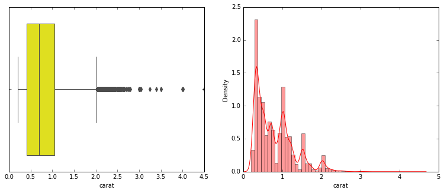

```python
fig, (ax1,ax2)=plt.subplots(1,2,figsize=(13,5))
sns.boxplot(df['carat'],orient='horizontal',color='yellow',ax=ax1)
sns.distplot(df['carat'],ax=ax2,color="red")
```

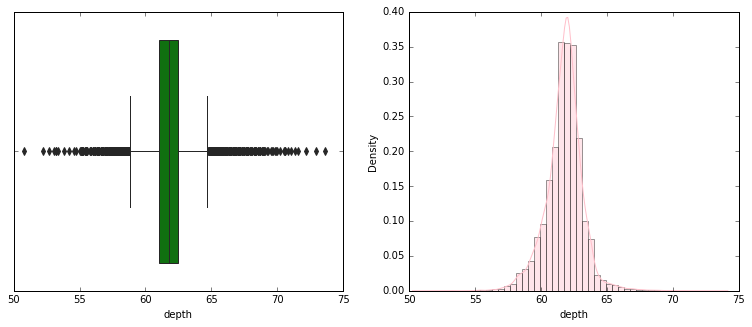

```python
fig, (ax1,ax2)=plt.subplots(1,2,figsize=(13,5))
sns.boxplot(df['depth'],orient='horizontal',color='green',ax=ax1)
sns.distplot(df['depth'],ax=ax2,color="pink")
```

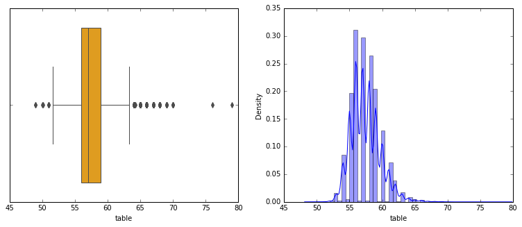

```python
fig, (ax1,ax2)=plt.subplots(1,2,figsize=(13,5))
sns.boxplot(df['table'],orient='horizontal',color='orange',ax=ax1)
sns.distplot(df['table'],ax=ax2,color="blue")
```

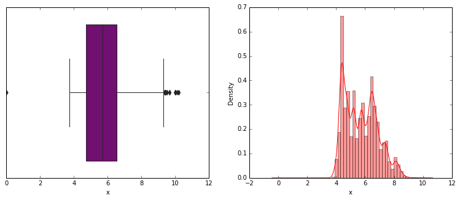

```python
fig, (ax1,ax2)=plt.subplots(1,2,figsize=(13,5))
sns.boxplot(df['x'],orient='horizontal',color='purple',ax=ax1)
sns.distplot(df['x'],ax=ax2,color="red")
```

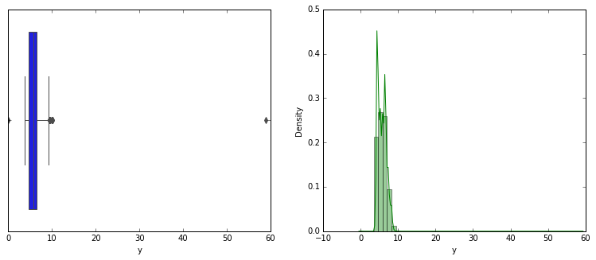

```python
fig, (ax1,ax2)=plt.subplots(1,2,figsize=(13,5))
sns.boxplot(df['y'],orient='horizontal',color='blue',ax=ax1)
sns.distplot(df['y'],ax=ax2,color="green")
```

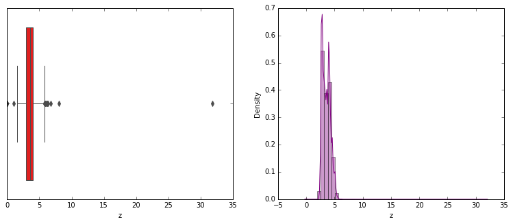

```python
fig, (ax1,ax2)=plt.subplots(1,2,figsize=(13,5))
sns.boxplot(df['z'],orient='horizontal',color='red',ax=ax1)
sns.distplot(df['z'],ax=ax2,color="purple")
```

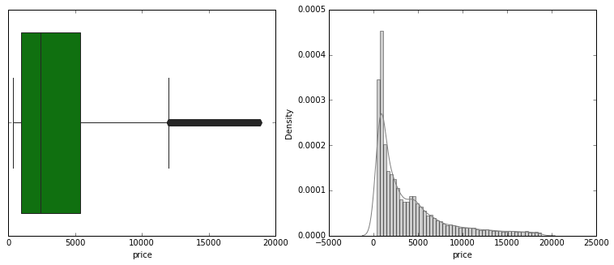

```python
fig, (ax1,ax2)=plt.subplots(1,2,figsize=(13,5))
sns.boxplot(df['price'],orient='horizontal',color='green',ax=ax1)
sns.distplot(df['price'],ax=ax2,color="grey")
```

```python
df.skew()
```

```
carat    1.116481
depth   -0.028618
table    0.765758
x        0.387986
y        3.850189
z        2.568257
price    1.618550
dtype: float64
```

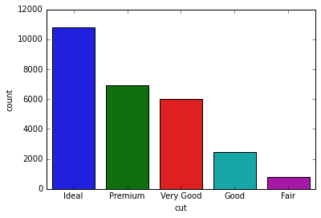

```python
sns.countplot(df["cut"])
```

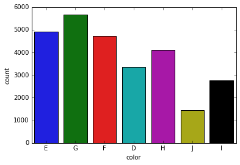

```python
sns.countplot(df["color"])
```

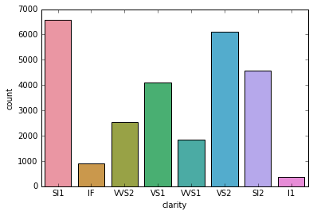

```python
sns.countplot(df["clarity"])
```

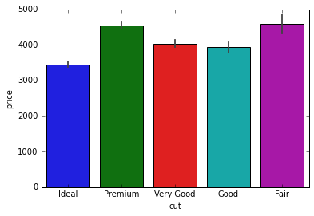

```python
sns.barplot(data = df, x='cut',y='price')
```

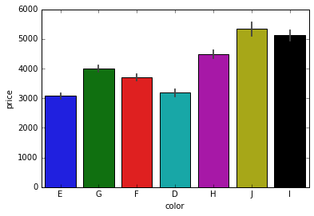

```python
sns.barplot(data = df, x='color',y='price')
```

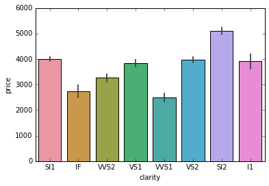

```python
sns.barplot(data = df, x='clarity',y='price')
```

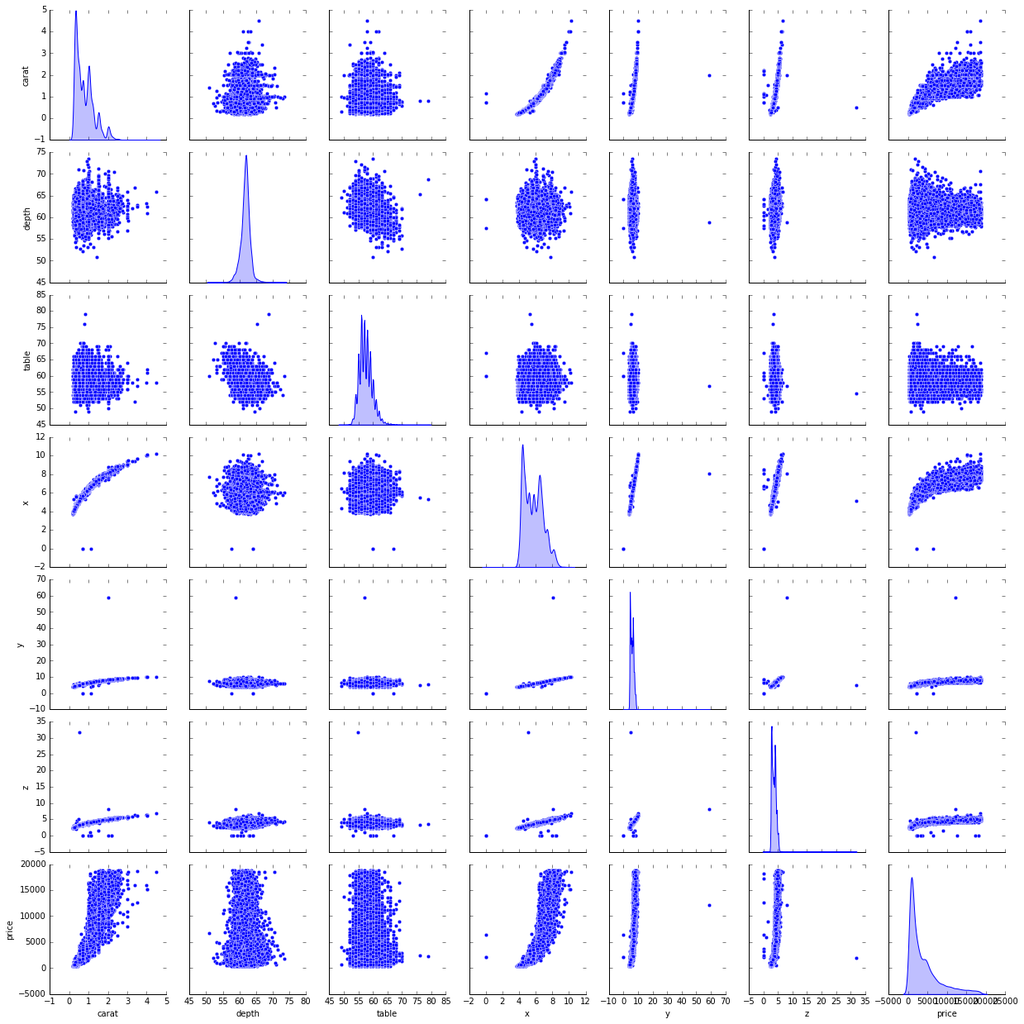

```python
sns.pairplot(df,diag_kind='kde');
```

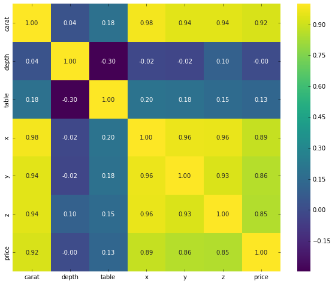

```python
plt.figure(figsize=(10,8))
sns.heatmap(df.corr(),annot=True,fmt=".2f",cmap="viridis")
plt.show()
```

```python
def check_outliers(data):
    vData_num = data.loc[:,data.columns != 'class']
    Q1 = vData_num.quantile(0.25)
    Q3 = vData_num.quantile(0.75)
    IQR = Q3 - Q1
    count = 0
    # checking for outliers, True represents outlier
    vData_num_mod = ((vData_num < (Q1 - 1.5 * IQR)) |(vData_num > (Q3 + 1.5 * IQR)))
    #iterating over columns to check for no.of outliers in each of the numerical attributes.
    for col in vData_num_mod:
        if(1 in vData_num_mod[col].value_counts().index):
            print("No. of outliers in %s: %d" %( col, vData_num_mod[col].value_counts().iloc[1]))
            count += 1
    print("\n\nNo of attributes with outliers are :", count)

check_outliers(df)
```

```
No. of outliers in carat: 662
No. of outliers in depth: 1225
No. of outliers in price: 1779
No. of outliers in table: 318
No. of outliers in x: 15
No. of outliers in y: 15
No. of outliers in z: 23


No of attributes with outliers are : 7
```

1.2 Impute null values if present, also check for the values which are equal to zero. Do they have any meaning or do we need to change them or drop them? Check for the possibility of combining the sub levels of a ordinal variables and take actions accordingly. Explain why you are combining these sub levels with appropriate reasoning.

```python
df.duplicated().sum()
```

```
34
```